# Risk Factor Analysis

## Outcome Variable

**Outcome Variable:** sstunted

## Predictor Variables

**Intervention Variable:** nhh

**Adjustment Set:**

- arm
- W_mage
- meducyrs
- feducyrs
- hhwealth_quart
- W_mhtcm
- W_mwtkg
- W_mbmi
- W_nrooms
- cleanck
- impfloor
- impsan
- safeh20
- delta_W_mage
- delta_meducyrs
- delta_feducyrs
- delta_hhwealth_quart
- delta_W_mhtcm
- delta_W_mwtkg
- delta_W_mbmi
- delta_W_nrooms
- delta_cleanck
- delta_impfloor
- delta_impsan
- delta_safeh20

## Stratifying Variables

The analysis was stratified on these variable(s):

- agecat
- studyid
- country

## Data Summary

| agecat | studyid | country | nhh | sstunted | n_cell | n |
| --- | --- | --- | --- | --- | --- | --- |
| Birth | ki1000108-IRC | INDIA | 3 or less | 0 | 53 | 388 |
| Birth | ki1000108-IRC | INDIA | 3 or less | 1 | 1 | 388 |
| Birth | ki1000108-IRC | INDIA | 4-5 | 0 | 142 | 388 |
| Birth | ki1000108-IRC | INDIA | 4-5 | 1 | 8 | 388 |
| Birth | ki1000108-IRC | INDIA | 6-7 | 0 | 97 | 388 |
| Birth | ki1000108-IRC | INDIA | 6-7 | 1 | 6 | 388 |
| Birth | ki1000108-IRC | INDIA | 8+ | 0 | 80 | 388 |
| Birth | ki1000108-IRC | INDIA | 8+ | 1 | 1 | 388 |
| Birth | ki1017093-NIH-Birth | BANGLADESH | 3 or less | 0 | 7 | 28 |
| Birth | ki1017093-NIH-Birth | BANGLADESH | 3 or less | 1 | 0 | 28 |
| Birth | ki1017093-NIH-Birth | BANGLADESH | 4-5 | 0 | 11 | 28 |
| Birth | ki1017093-NIH-Birth | BANGLADESH | 4-5 | 1 | 0 | 28 |
| Birth | ki1017093-NIH-Birth | BANGLADESH | 6-7 | 0 | 7 | 28 |
| Birth | ki1017093-NIH-Birth | BANGLADESH | 6-7 | 1 | 0 | 28 |
| Birth | ki1017093-NIH-Birth | BANGLADESH | 8+ | 0 | 3 | 28 |
| Birth | ki1017093-NIH-Birth | BANGLADESH | 8+ | 1 | 0 | 28 |
| Birth | ki1017093c-NIH-Crypto | BANGLADESH | 3 or less | 0 | 8 | 27 |
| Birth | ki1017093c-NIH-Crypto | BANGLADESH | 3 or less | 1 | 0 | 27 |
| Birth | ki1017093c-NIH-Crypto | BANGLADESH | 4-5 | 0 | 9 | 27 |
| Birth | ki1017093c-NIH-Crypto | BANGLADESH | 4-5 | 1 | 0 | 27 |
| Birth | ki1017093c-NIH-Crypto | BANGLADESH | 6-7 | 0 | 6 | 27 |
| Birth | ki1017093c-NIH-Crypto | BANGLADESH | 6-7 | 1 | 1 | 27 |
| Birth | ki1017093c-NIH-Crypto | BANGLADESH | 8+ | 0 | 3 | 27 |
| Birth | ki1017093c-NIH-Crypto | BANGLADESH | 8+ | 1 | 0 | 27 |
| 6 months | ki1000108-IRC | INDIA | 3 or less | 0 | 55 | 407 |
| 6 months | ki1000108-IRC | INDIA | 3 or less | 1 | 3 | 407 |
| 6 months | ki1000108-IRC | INDIA | 4-5 | 0 | 145 | 407 |
| 6 months | ki1000108-IRC | INDIA | 4-5 | 1 | 13 | 407 |
| 6 months | ki1000108-IRC | INDIA | 6-7 | 0 | 98 | 407 |
| 6 months | ki1000108-IRC | INDIA | 6-7 | 1 | 8 | 407 |

[output cut: 82 more lines]

The following strata were considered:

- agecat: 24 months, studyid: ki1000108-IRC, country: INDIA
- agecat: 24 months, studyid: ki1017093-NIH-Birth, country: BANGLADESH
- agecat: 24 months, studyid: ki1017093b-PROVIDE, country: BANGLADESH
- agecat: 24 months, studyid: ki1017093c-NIH-Crypto, country: BANGLADESH
- agecat: 24 months, studyid: ki1148112-LCNI-5, country: MALAWI
- agecat: 6 months, studyid: ki1000108-IRC, country: INDIA
- agecat: 6 months, studyid: ki1000304b-SAS-FoodSuppl, country: INDIA
- agecat: 6 months, studyid: ki1017093-NIH-Birth, country: BANGLADESH
- agecat: 6 months, studyid: ki1017093b-PROVIDE, country: BANGLADESH
- agecat: 6 months, studyid: ki1017093c-NIH-Crypto, country: BANGLADESH
- agecat: 6 months, studyid: ki1148112-LCNI-5, country: MALAWI
- agecat: Birth, studyid: ki1000108-IRC, country: INDIA
- agecat: Birth, studyid: ki1017093-NIH-Birth, country: BANGLADESH
- agecat: Birth, studyid: ki1017093c-NIH-Crypto, country: BANGLADESH

### Dropped Strata

Some strata were dropped due to rare outcomes:

- agecat: Birth, studyid: ki1000108-IRC, country: INDIA
- agecat: Birth, studyid: ki1017093-NIH-Birth, country: BANGLADESH
- agecat: Birth, studyid: ki1017093c-NIH-Crypto, country: BANGLADESH
- agecat: 6 months, studyid: ki1000108-IRC, country: INDIA
- agecat: 6 months, studyid: ki1000304b-SAS-FoodSuppl, country: INDIA
- agecat: 6 months, studyid: ki1017093-NIH-Birth, country: BANGLADESH
- agecat: 6 months, studyid: ki1017093b-PROVIDE, country: BANGLADESH
- agecat: 6 months, studyid: ki1017093c-NIH-Crypto, country: BANGLADESH
- agecat: 24 months, studyid: ki1000108-IRC, country: INDIA
- agecat: 24 months, studyid: ki1017093c-NIH-Crypto, country: BANGLADESH

## Methods Detail

We’re interested in the causal parameters $E[Y_a]$ for all values of $a \in \mathcal{A}$. These parameters represent the mean outcome if, possibly contrary to fact, we intervened to set all units to have $A=a$. Under the randomization and positivity assumptions, these are identified by the statistical parameters $\psi_a=E_W[E_{Y|A,W}(Y|A=a,W)]$. In addition, we’re interested in the mean of $Y$, $E[Y]$ under no intervention (the observed mean). We will estimate these parameters by using SuperLearner to fit the relevant likelihood factors – $E_{Y|A,W}(Y|A=a,W)$ and $p(A=a|W)$, and then updating our likelihood fit using a joint TMLE.

For unadjusted analyses ($W=\{\}$), initial likelihoods were estimated using Lrnr_glm to estimate the simple $E(Y|A)$ and Lrnr_mean to estimate $p(A)$. For adjusted analyses, a small library containing Lrnr_glmnet, Lrnr_xgboost, and Lrnr_mean was used.

Having estimated these parameters, we will then use the delta method to estimate relative risks and attributable risks relative to a prespecified baseline level of $A$.

# Results Detail

## Results Plots

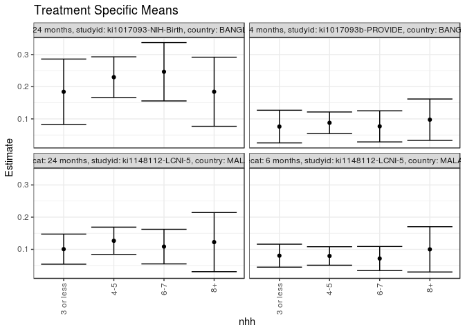

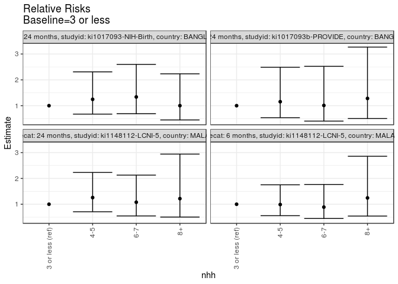

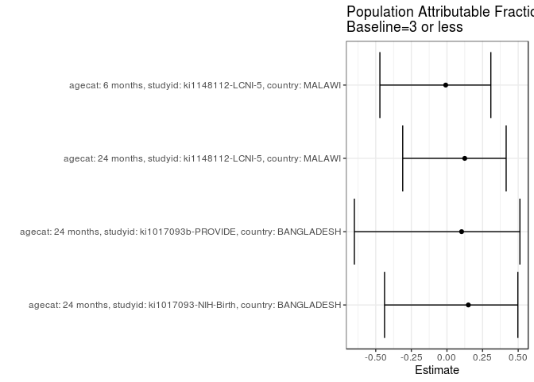

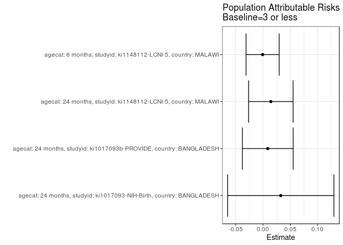

## Results Table

### Parameter: TSM

| agecat | studyid | country | intervention_level | baseline_level | estimate | ci_lower | ci_upper |
| --- | --- | --- | --- | --- | --- | --- | --- |
| 6 months | ki1148112-LCNI-5 | MALAWI | 3 or less | NA | 0.0803571 | 0.0447356 | 0.1159786 |
| 6 months | ki1148112-LCNI-5 | MALAWI | 4-5 | NA | 0.0794118 | 0.0506543 | 0.1081692 |
| 6 months | ki1148112-LCNI-5 | MALAWI | 6-7 | NA | 0.0714286 | 0.0339897 | 0.1088674 |
| 6 months | ki1148112-LCNI-5 | MALAWI | 8+ | NA | 0.1000000 | 0.0296787 | 0.1703213 |
| 24 months | ki1017093-NIH-Birth | BANGLADESH | 3 or less | NA | 0.1842453 | 0.0825672 | 0.2859233 |
| 24 months | ki1017093-NIH-Birth | BANGLADESH | 4-5 | NA | 0.2295876 | 0.1663783 | 0.2927969 |
| 24 months | ki1017093-NIH-Birth | BANGLADESH | 6-7 | NA | 0.2464511 | 0.1558076 | 0.3370946 |
| 24 months | ki1017093-NIH-Birth | BANGLADESH | 8+ | NA | 0.1843878 | 0.0770672 | 0.2917084 |
| 24 months | ki1017093b-PROVIDE | BANGLADESH | 3 or less | NA | 0.0761905 | 0.0254012 | 0.1269797 |
| 24 months | ki1017093b-PROVIDE | BANGLADESH | 4-5 | NA | 0.0879121 | 0.0542930 | 0.1215312 |
| 24 months | ki1017093b-PROVIDE | BANGLADESH | 6-7 | NA | 0.0769231 | 0.0285973 | 0.1252489 |
| 24 months | ki1017093b-PROVIDE | BANGLADESH | 8+ | NA | 0.0975610 | 0.0332826 | 0.1618393 |
| 24 months | ki1148112-LCNI-5 | MALAWI | 3 or less | NA | 0.1006289 | 0.0538275 | 0.1474304 |
| 24 months | ki1148112-LCNI-5 | MALAWI | 4-5 | NA | 0.1265823 | 0.0842131 | 0.1689515 |
| 24 months | ki1148112-LCNI-5 | MALAWI | 6-7 | NA | 0.1085271 | 0.0548048 | 0.1622495 |
| 24 months | ki1148112-LCNI-5 | MALAWI | 8+ | NA | 0.1224490 | 0.0305856 | 0.2143124 |

### Parameter: E(Y)

| agecat | studyid | country | intervention_level | baseline_level | estimate | ci_lower | ci_upper |
| --- | --- | --- | --- | --- | --- | --- | --- |
| 6 months | ki1148112-LCNI-5 | MALAWI | NA | NA | 0.0796569 | 0.0610679 | 0.0982459 |
| 24 months | ki1017093-NIH-Birth | BANGLADESH | NA | NA | 0.2167832 | 0.1777459 | 0.2558205 |
| 24 months | ki1017093b-PROVIDE | BANGLADESH | NA | NA | 0.0849220 | 0.0621566 | 0.1076874 |
| 24 months | ki1148112-LCNI-5 | MALAWI | NA | NA | 0.1149826 | 0.0888632 | 0.1411019 |

### Parameter: RR

| agecat | studyid | country | intervention_level | baseline_level | estimate | ci_lower | ci_upper |
| --- | --- | --- | --- | --- | --- | --- | --- |
| 6 months | ki1148112-LCNI-5 | MALAWI | 3 or less | 3 or less | 1.0000000 | 1.0000000 | 1.000000 |
| 6 months | ki1148112-LCNI-5 | MALAWI | 4-5 | 3 or less | 0.9882353 | 0.5575312 | 1.751667 |
| 6 months | ki1148112-LCNI-5 | MALAWI | 6-7 | 3 or less | 0.8888889 | 0.4474248 | 1.765936 |
| 6 months | ki1148112-LCNI-5 | MALAWI | 8+ | 3 or less | 1.2444444 | 0.5419491 | 2.857541 |
| 24 months | ki1017093-NIH-Birth | BANGLADESH | 3 or less | 3 or less | 1.0000000 | 1.0000000 | 1.000000 |
| 24 months | ki1017093-NIH-Birth | BANGLADESH | 4-5 | 3 or less | 1.2460976 | 0.6723624 | 2.309408 |
| 24 months | ki1017093-NIH-Birth | BANGLADESH | 6-7 | 3 or less | 1.3376252 | 0.6886713 | 2.598106 |
| 24 months | ki1017093-NIH-Birth | BANGLADESH | 8+ | 3 or less | 1.0007735 | 0.4484885 | 2.233162 |
| 24 months | ki1017093b-PROVIDE | BANGLADESH | 3 or less | 3 or less | 1.0000000 | 1.0000000 | 1.000000 |
| 24 months | ki1017093b-PROVIDE | BANGLADESH | 4-5 | 3 or less | 1.1538462 | 0.5350416 | 2.488332 |
| 24 months | ki1017093b-PROVIDE | BANGLADESH | 6-7 | 3 or less | 1.0096154 | 0.4039656 | 2.523292 |
| 24 months | ki1017093b-PROVIDE | BANGLADESH | 8+ | 3 or less | 1.2804878 | 0.5015670 | 3.269053 |
| 24 months | ki1148112-LCNI-5 | MALAWI | 3 or less | 3 or less | 1.0000000 | 1.0000000 | 1.000000 |
| 24 months | ki1148112-LCNI-5 | MALAWI | 4-5 | 3 or less | 1.2579114 | 0.7092413 | 2.231034 |
| 24 months | ki1148112-LCNI-5 | MALAWI | 6-7 | 3 or less | 1.0784884 | 0.5468044 | 2.127154 |
| 24 months | ki1148112-LCNI-5 | MALAWI | 8+ | 3 or less | 1.2168367 | 0.5033692 | 2.941562 |

### Parameter: PAR

| agecat | studyid | country | intervention_level | baseline_level | estimate | ci_lower | ci_upper |
| --- | --- | --- | --- | --- | --- | --- | --- |
| 6 months | ki1148112-LCNI-5 | MALAWI | 3 or less | NA | -0.0007003 | -0.0309954 | 0.0295949 |
| 24 months | ki1017093-NIH-Birth | BANGLADESH | 3 or less | NA | 0.0325380 | -0.0646756 | 0.1297515 |
| 24 months | ki1017093b-PROVIDE | BANGLADESH | 3 or less | NA | 0.0087315 | -0.0377333 | 0.0551964 |
| 24 months | ki1148112-LCNI-5 | MALAWI | 3 or less | NA | 0.0143536 | -0.0263786 | 0.0550859 |

### Parameter: PAF

| agecat | studyid | country | intervention_level | baseline_level | estimate | ci_lower | ci_upper |
| --- | --- | --- | --- | --- | --- | --- | --- |
| 6 months | ki1148112-LCNI-5 | MALAWI | 3 or less | NA | -0.0087912 | -0.4707235 | 0.3080551 |
| 24 months | ki1017093-NIH-Birth | BANGLADESH | 3 or less | NA | 0.1500944 | -0.4380560 | 0.4976973 |
| 24 months | ki1017093b-PROVIDE | BANGLADESH | 3 or less | NA | 0.1028183 | -0.6498906 | 0.5121282 |
| 24 months | ki1148112-LCNI-5 | MALAWI | 3 or less | NA | 0.1248332 | -0.3105309 | 0.4155675 |